# Data Dictionary: *sport_sampling* database

Are Strom

2018-08-30

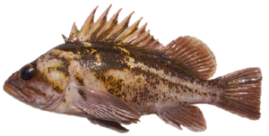

# Introduction

The Washington Department of Fish and Wildlife (WDFW) *sport_sampling* database, described below, is intended as a central repository for recreational fisheries data collected by the WDFW Puget Sound Sampling Program, the Ocean Sampling program, and the Columbia River Sport Sampling Program. The aim is to provide a common framework for the collection, storage, retrieval, and dissemination of fishery survey data collected by these programs.

#### Rationale

Development of the *sport_sampling* database was spurred primarily by two factors:

- The need by harvest managers to consolidate disparate sets of data into one central location.
- The need to simplify sharing of data with outside entities.

Prior to development of the *sport_sampling* database, data collected during surveys such as dockside creel surveys, aerial surveys, and test-fishing surveys, were manually entered into multiple stand-alone Access databases and spreadsheets. New versions of these databases and spreadsheets were then re-created each year. To estimate harvest or conduct analyses, considerable effort was required to combine these data. Analysis of trends over multiple years was particularly challenging. The process of merging disparate datasets would often expose errors that could have been avoided by having all data centralized in a properly structured database from the outset. In addition, the advent of mobile data collection technologies provided an opportunity to reduce both the cost and errors that typically result when transcribing data from paper to computer. To automate data collection and data entry a central database was needed.

To facilitate data sharing, the *sport_sampling* database has been intentionally designed using technology and features that make it easier to integrate data from multiple groups (programs) within the agency. For example, by using universally unique IDs (uuid) for database keys, the need for central coordination in assigning database keys has been eliminated. By hosting the database in the AWS cloud rather than on WDFW servers, there is more flexibility in engineering secure solutions to allow outside entities to easily access and use the data.

#### Notes on table descriptions

The sections below document table and field definitions for the *sport_sampling* database. Table descriptions are arranged in descending order starting with top-level header data for individual surveys, and ending with tables that store data for individual fish or individual redds. Each section describes one *data* table.

Within each section, finer-grained descriptions of columns are provided for each table. For cases where columns link to a set of look-up table values, the relevant look-up tables are displayed directly below the table descriptions.

The final four columns of each *data* table include:

- *created_datetime*: timestamptz(6)
- *created_by*: varchar(16)
- *modified_datetime*: timestamptz(6)
- *modified_by*: varchar(16)

These columns document the *time* (with timezone) that each record was created or modified, and the *individual* or *application* that created or modified the record. For brevity these columns will not be included in the *data* table descriptions below, but should be assumed to be present.

Look-up tables can be identified by the underscore *lut* suffix in the table name. For example, *data_source_lut*. The final two columns of each *look-up* table include:

- *obsolete_flag*: boolean
- *obsolete_datetime* timestamptz(6)

These columns document if a field has been *retired* or deemed *obsolete*, along with the date when the field was retired. For brevity these columns will not be included in the *look-up* table descriptions below, but should be assumed to be present.

Look-up tables that are linked to more than one data tables, such as species_lut are only displayed once, normally beneath the first data table in which it is used. Please use the database diagram to identify all occurrances.

Values recorded in each look-up table are displayed directly below the field definitions.

#### Disclaimer

The *sport_sampling* database is a work in progress and is subject to change. If you have any questions please contact the data manager Are Strom (Are.Strom@dfw.wa.gov).

# Database diagram

[interactive chart not shown]

# Survey

##### *Top level header information for surveys*

| Column name | Data type | Nullable? | Key | Description |
| --- | --- | --- | --- | --- |
| survey_id | uuid | No | Primary | Universally unique primary key |
| survey_type_id | uuid | No | Foreign | Type of survey (Puget Sound creel, aerial, etc.) |
| survey_design_type_id | uuid | Yes | Foreign | Survey design used to monitor fishery (murthy, baseline, etc.) |
| sampling_program_id | uuid | No | Foreign | Sampling program or unit that conducted survey |
| location_id | uuid | No | Foreign | Location where survey was conducted |
| data_review_status_id | uuid | No | Foreign | Status of data review (final, preliminary, etc.) |
| survey_completion_status_id | uuid | No | Foreign | Was survey completed (partial, completed, etc.) |
| survey_datetime | timestamptz (6) | No |  | Date of survey |
| start_datetime | timestamptz (6) | Yes |  | Start time of survey |
| end_datetime | timestamptz (6) | Yes |  | End time of survey |
| no_effort_indicator | bool | No |  | Flag for no survey encounters |
| comment_text | text | Yes |  | Additional survey comments |

### survey_type_lut

##### *Type of survey conducted (Puget Sound creel, aerial, etc.)*

| Column name | Data type | Nullable? | Key | Description |
| --- | --- | --- | --- | --- |
| survey_type_id | uuid | No | Primary | Universally unique primary key |
| survey_type_description | text | No |  | Description of survey type |

| survey_type_id | survey_type_description |
| --- | --- |
| b5967130-69ff-49b6-b300-5501e60ec349 | Lower Columbia River creel survey |
| 9c716688-c717-405d-93ea-83da15e46417 | OSP Sport Interview Survey |
| c29b9752-6c0e-4e45-9eac-5e450dd10dcc | Puget Sound aerial boat count survey |
| 67909653-e362-4007-8ebf-648ca0508625 | Puget Sound boat exit count survey |
| 9472b010-806d-4e1f-8b5b-f356e5e0a7c0 | Puget Sound boat ramp effort proportion survey |
| a1c68f6d-dcfe-4b86-a00d-d8fab7057e2e | Puget Sound dockside creel survey |
| bf20fffe-17ad-423e-9802-090bcd1ba3cf | Puget Sound shore effort survey |
| 3d07d72c-18a6-47c4-805b-bd756afab088 | Puget Sound test fishing survey |
| 1dca9e54-1d3d-45fb-8d5a-de9054eb1503 | Puget Sound voluntary trip report |

### survey_design_type_lut

##### *Survey design used to monitor fishery (murthy, baseline, etc.)*

| Column name | Data type | Nullable? | Key | Description |
| --- | --- | --- | --- | --- |
| survey_design_type_id | uuid | No | Primary | Universally unique primary key |
| survey_design_type_description | text | No |  | Description of survey design categories |

| survey_design_type_id | survey_design_type_description |
| --- | --- |
| 029a5131-8328-4d42-83e7-0010d1dccec2 | Full Murthy Aerial |
| 9f86ef7c-df10-407d-be87-0d25db3887c6 | Exploratory Reduced Murthy |
| c92551ee-ea12-4c67-ad79-17925e4338dd | No data |
| 4db3849e-0ac0-47b0-bd79-51c4ee744572 | Baseline |
| 10505fdc-6f5d-4bca-b372-6c6c2f3464d1 | Full Murthy |
| 16c26d10-0d67-46f7-a529-6c8abf9e2858 | Reduced Murthy Aerial |
| 0c464f71-8487-44e2-b60e-737a307e822e | Not applicable |
| 299534bb-4a27-49ae-94f2-7b1de26b6ec3 | Reduced Murthy |

### sampling_program_lut

##### *Sampling program or unit that conducted survey*

| Column name | Data type | Nullable? | Key | Description |
| --- | --- | --- | --- | --- |
| sampling_program_id | uuid | No | Primary | Universally unique primary key |
| agency_id | uuid | No | Foreign | Parent agency of sampling program |
| sampling_program_code | varchar (10) | No |  | Sampling program code |
| sampling_program_name | varchar (100) | No |  | Sampling program name |

| sampling_program_id | agency_id | sampling_program_code | sampling_program_name |
| --- | --- | --- | --- |
| eb7f8224-7dc7-4f14-8699-7788e6b1be4f | bbe4126e-6081-44e3-af1b-012c98290603 | CRSSP | Columbia River Sport Sampling Program |
| 1908cc7d-ef42-4345-9285-8961096c8613 | bbe4126e-6081-44e3-af1b-012c98290603 | PSSP | Puget Sound Sampling Program |
| 305d3c35-06d8-402e-9dc6-b4a830318869 | bbe4126e-6081-44e3-af1b-012c98290603 | OSP | Ocean Sampling Program |

### agency_lut

##### *Agency or organization that conducted survey*

| Column name | Data type | Nullable? | Key | Description |
| --- | --- | --- | --- | --- |
| agency_id | uuid | No | Primary | Universally unique primary key |
| agency_code | varchar (10) | No |  | Short code for agency |
| agency_name | varchar (100) | No |  | Agency name |

| agency_id | agency_code | agency_name |
| --- | --- | --- |
| bbe4126e-6081-44e3-af1b-012c98290603 | WDFW | Washington Department of Fish & Wildlife |
| 9455db7d-f502-4c14-ac6d-5ea75be54245 | NWIFC | Northwest Indian Fisheries Commission |

### data_review_status_lut

##### *Status of data review process*

| Column name | Data type | Nullable? | Key | Description |
| --- | --- | --- | --- | --- |
| data_review_status_id | uuid | No | Primary | Universally unique primary key |
| data_review_status_description | varchar (25) | No |  | Description of review categories |

| data_review_status_id | data_review_status_description |
| --- | --- |
| 48d228a2-6cdc-48e6-95e9-09b5e21d6489 | Preliminary |
| bdefcb1f-80c4-4921-9cf4-66c8dde02d4b | Final |
| acc0bee1-8404-4a52-b052-b176e5863cf8 | Unknown |
| cfc533e5-d5ef-44dc-ae1b-b5a3cfd59016 | Not applicable |
| 59cbf9d7-9015-49b6-874d-ea37ef663c56 | Reviewed |

### survey_completion_status_lut

##### *Was the survey completed?*

| Column name | Data type | Nullable? | Key | Description |
| --- | --- | --- | --- | --- |
| survey_completion_status_id | uuid | No | Primary | Universally unique primary key |
| completion_status_description | varchar (100) | No |  | Description of status categories |

| survey_completion_status_id | completion_status_description |
| --- | --- |
| 149d7253-6a25-4c4c-a7e2-a6cbbbb9850a | No survey conducted |
| 71ab2649-62d9-4d48-bad1-0b8a41f352a4 | Unknown |
| 9c72357a-8e98-4c98-888c-3412902bf0bf | Partial survey |
| d192b32e-0e4f-4719-9c9c-dec6593b1977 | Completed survey |

# Location

##### *Data associated with locations, includes both point locations and areas*

| Column name | Data type | Nullable? | Key | Description |
| --- | --- | --- | --- | --- |
| location_id | uuid | No | Primary | Universally unique primary key |
| location_type_id | uuid | No | Foreign | Type of location (dock, pier, etc.) |
| location_code | varchar (10) | Yes |  | Short code to identify location |
| location_name | varchar (100) | Yes |  | Name of location (place name, etc.) |
| location_description | text | Yes |  | Extended description of location |
| active_indicator | bool | No |  | Flag indicating if location is still in use |
| active_datetime | timestamptz (6) | Yes |  | Date that location became available or active |
| inactive_datetime | timestamptz (6) | Yes |  | Date that location became unavailable or inactive |
| inactive_reason_text | text | Yes |  | Reason that location became unavailable or inactive |
| comment_text | text | Yes |  | Additional comments on location |

### location_type_lut

##### *Type of location (dock, pier, etc.)*

| Column name | Data type | Nullable? | Key | Description |
| --- | --- | --- | --- | --- |
| location_type_id | uuid | No | Primary | Universally unique primary key |
| location_type_description | varchar (50) | No |  | Description of the location type |

| location_type_id | location_type_description |
| --- | --- |
| 1ea72e34-6e52-49d2-bd1f-1820827fdb94 | Unknown |
| 31e29406-ff29-4d87-8809-2a7dc37f35fd | WDFW office |
| edf5a5b2-ce32-4550-81c0-40fe6505d84d | Beach |
| fcf11156-2692-4581-a27c-4e177bcf9a0d | Marina |
| 995d4caf-e4fd-4ed7-85f5-99ddad05fcd5 | Pier |
| 017ef540-3f0e-4ac6-b1cd-b6796bdab5f7 | Ramp |
| b31d5220-7f6d-4686-87b6-ba4120327b83 | Sling |
| 7d1a431c-a55c-4264-9f3e-ccdaf4c5f7fd | Duty station |
| a06fe17f-b88b-4d91-8a0a-e43ecc9b3e24 | Not applicable |
| 120334ed-29fa-415c-a457-eced69eae459 | Dock |
| e75b998d-ef12-42c3-93ff-0a4ad9528c38 | DNA sample recovery site |
| 07b8b7b3-10ec-4727-9a74-1ac2dd2b5120 | CWT sample recovery site |
| 7cf1d6aa-5a2f-474b-b095-3ce51e6467ec | Special Area Fishery |
| fc2162b9-ae56-457c-a073-6fc53b2abf4a | Catch Record Card area |
| 7a72d2ee-8d21-4cb6-ac4b-9cb85cd8c02c | Media recording point |

# Location_boundary

##### *Spatial table holding boundary polygons for location areas*

| Column name | Data type | Nullable? | Key | Description |
| --- | --- | --- | --- | --- |
| location_boundary_id | uuid | No | Primary | Universally unique primary key |
| location_id | uuid | No | Foreign | Link to location table |
| gid | int4 | No |  | Unique integer ID, required to manually edit geometry |
| geom | geometry | No |  | Polygons of the location boundaries stored in binary format, EPSG:2927 |

# Location_coordinates

##### *Spatial table holding coordinates (when available) for point_location records*

| Column name | Data type | Nullable? | Key | Description |
| --- | --- | --- | --- | --- |
| location_coordinates_id | uuid | No | Primary | Universally unique primary key |
| location_id | uuid | No | Foreign | Link to location table |
| longitude | numeric (14, 9) | Yes |  | Longitude in decimal degrees, EPSG:4326 |
| latitude | numeric (12, 9) | Yes |  | Latitude in decimal degrees, EPSG:4326 |
| horizontal_accuracy | numeric (6, 2) | Yes |  | Estimated accuracy of the point in meters |
| gid | int4 | No |  | Unique integer ID, required to manually edit geometry |
| geom | geometry | No |  | Points stored in binary format. EPSG:2927 |

# Media_location

##### *Identifies where to retrieve media (photo, video, audio files, etc.) recorded at point locations*

| Column name | Data type | Nullable? | Key | Description |
| --- | --- | --- | --- | --- |
| media_location_id | uuid | No | Primary | Universally unique primary key |
| location_id | uuid | No | Foreign | Link to location table |
| media_type_id | uuid | No | Foreign | The type of media that was recorded (photo, video, audio, etc.) |
| media_url | text | No |  | The secure file or web location where media files are stored |

### media_type_lut

##### *Type of media that was recorded (photo, video, audio, etc.)*

| Column name | Data type | Nullable? | Key | Description |
| --- | --- | --- | --- | --- |
| media_type_id | uuid | No | Primary | Universally unique primary key |
| media_type_code | varchar (25) | No |  | Code describing the type of media |
| media_type_description | varchar (200) | No |  | Description of the media type |

| media_type_id | media_type_code | media_type_description |
| --- | --- | --- |
| ad673e4b-51d2-4eaf-b3bc-3159a504e6c9 | Photo | Photo capture |
| 8f89025d-d674-451e-bcb7-ab8567c648e1 | Video | Video recording |
| bad7dad2-600e-4586-8428-3fbe26f5b70b | Audio | Audio recording |

# Boat_count_omitted

##### *Table to record counts of boats not fishing or boats missed*

| Column name | Data type | Nullable? | Key | Description |
| --- | --- | --- | --- | --- |
| boat_count_omitted_id | uuid | No | Primary | Universally unique primary key |
| survey_id | uuid | No | Foreign | Link to survey table |
| boat_not_fishing_count | int4 | Yes |  | Count of boats not fishing |
| boat_missed_count | int4 | Yes |  | Count of boats missed |

# Boat_trailer

##### *Counts of boat trailers*

| Column name | Data type | Nullable? | Key | Description |
| --- | --- | --- | --- | --- |
| boat_trailer_id | uuid | No | Primary | Universally unique primary key |
| survey_id | uuid | No | Foreign | Link to survey table |
| trailer_location_id | uuid | Yes | Foreign | Link to location table |
| start_survey_trailer_count | int4 | No |  | Time trailer count started |
| end_survey_trailer_count | int4 | No |  | Time trailer count ended |
| comment_text | text | Yes |  | Additional comments for trailer counts |

# Released_legal_fish

##### *Counts of legal fish that were released*

| Column name | Data type | Nullable? | Key | Description |
| --- | --- | --- | --- | --- |
| released_legal_fish_id | uuid | No | Primary | Universally unique primary key |
| survey_id | uuid | No | Foreign | Link to survey table |
| species_id | uuid | No | Foreign | Link to species table |
| released_legal_fish_count | int4 | No |  | Count of legal fish released |

### species_lut

##### *List of fish species*

| Column name | Data type | Nullable? | Key | Description |
| --- | --- | --- | --- | --- |
| species_id | uuid | No | Primary | Universally unique primary key |
| species_group_id | uuid | No | Foreign | Group species belongs to (salmon, marine, etc.) |
| taxo_name_id | int4 | Yes |  | External link to WDFW taxo_name table |
| species_code | varchar (3) | No |  | Short code for species |
| common_name | varchar (100) | No |  | Common name of species |
| genus | varchar (50) | Yes |  | The genus name for the fish |
| species | varchar (50) | Yes |  | The species name for the fish |

| species_id | species_group_id | taxo_name_id | species_code | common_name | genus | species |
| --- | --- | --- | --- | --- | --- | --- |
| 9f1ea31c-916e-46c9-8f32-66b3b1ae1c95 | b880f2c3-e29b-4114-82cb-92980a75c358 | 2123 | 226 | Albacore | Thunnus | alalunga |
| 274dc547-100d-485c-a961-01cd7982ad99 | 540413a3-5467-4e9b-b497-d4c58280c76d | 845 | 217 | American shad | Alosa | sapidissima |
| 0bca08eb-6db1-4ed9-80d2-fd2cc2531832 | b880f2c3-e29b-4114-82cb-92980a75c358 | 2147 | 213 | Arrowtooth flounder | Atheresthes | stomias |
| 37772a70-d2ec-41e6-991e-5c4fd7cb6ce7 | 540413a3-5467-4e9b-b497-d4c58280c76d | 1256 | 108 | Atlantic Salmon | Salmo | salar |
| 59f65844-b6e6-4c07-aad5-360c9ca52461 | b880f2c3-e29b-4114-82cb-92980a75c358 | 1437 | 266 | Aurora rockfish | Sebastes | aurora |
| e6976fc7-5875-4242-9496-dd0c399eb364 | b880f2c3-e29b-4114-82cb-92980a75c358 |  | 222 | Baitfish - general |  |  |
| 8d675bc6-f040-4e25-8a6b-fc47cf98ae8c | b880f2c3-e29b-4114-82cb-92980a75c358 | 808 | 287 | Big skate | Raja | binoculata |
| be0ee58a-57dc-410c-8941-bd5bdf240b13 | b880f2c3-e29b-4114-82cb-92980a75c358 | 1465 | 252 | Black rockfish | Sebastes | melanops |
| 4a0acb82-39da-412d-8ad8-75f0df795fa5 | b880f2c3-e29b-4114-82cb-92980a75c358 | 1469 | 262 | Blue rockfish | Sebastes | mystinus |
| 9d3d96fa-2aaa-4927-b970-b6419c265d36 | b880f2c3-e29b-4114-82cb-92980a75c358 | 788 | 281 | Blue shark | Prionace | glauca |
| 6f30c81f-9fcb-4c3a-b616-af034b7ed756 | b880f2c3-e29b-4114-82cb-92980a75c358 | 1473 | 257 | Bocaccio | Sebastes | paucispinis |
| 0f7a7159-f1f8-4917-9291-a60a5bc751e1 | b880f2c3-e29b-4114-82cb-92980a75c358 | 1566 | 292 | Brown Irish Lord | Hemilepidotus | spinosus |
| 73499a78-a605-49f5-9e80-4a6f1a6a93b5 | b880f2c3-e29b-4114-82cb-92980a75c358 | 1436 | 264 | Brown rockfish | Sebastes | auriculatus |
| 0b9f485e-75d8-45f5-9ab0-8228a44a5f24 | b880f2c3-e29b-4114-82cb-92980a75c358 | 1555 | 296 | Buffalo sculpin | Enophrys | bison |
| c7adf208-a3f8-4459-953c-9931b6f6ae09 | b880f2c3-e29b-4114-82cb-92980a75c358 | 2161 | 203 | Butter sole | Isopsetta | isolepis |
| 8a23680b-18dd-4720-b4d5-14cc0c7cb293 | b880f2c3-e29b-4114-82cb-92980a75c358 | 2165 | 204 | C-O sole | Pleuronichthys | coenosus |
| ff8ab6ec-bc36-4818-82ac-93fc218b65c5 | b880f2c3-e29b-4114-82cb-92980a75c358 | 1617 | 291 | Cabezon | Scorpaenichthys | marmoratus |
| ed34e09b-6b06-465a-97bb-6cf157d2cd28 | b880f2c3-e29b-4114-82cb-92980a75c358 | 1475 | 271 | Canary rockfish | Sebastes | pinniger |
| b73f7302-0f6c-4ebd-97bd-6a0ccef49fdb | b880f2c3-e29b-4114-82cb-92980a75c358 | 1457 | 267 | Chilipepper | Sebastes | goodei |
| dfb56be7-bae0-42f4-bd4f-0df67127fda7 | b880f2c3-e29b-4114-82cb-92980a75c358 | 1470 | 263 | China rockfish | Sebastes | nebulosus |
| f5291fb2-e033-4533-87e6-e1406c392aec | c2f4d533-d03f-4375-9124-64906e5b859c | 1249 | 101 | Chinook Salmon | Oncorhynchus | tshawytscha |
| c1b6e5fb-4b3d-408f-8a49-ad0250f9749d | b880f2c3-e29b-4114-82cb-92980a75c358 | 2120 | 227 | Chub mackerel | Scomber | japonicus |
| ba35f6af-6f3e-4d98-ba66-f53f80e7bc0c | c2f4d533-d03f-4375-9124-64906e5b859c | 1244 | 102 | Chum Salmon | Oncorhynchus | keta |
| 3c864d9e-d48b-46b1-970e-99a5351fabdd | b880f2c3-e29b-4114-82cb-92980a75c358 |  | 245 | Cod-general |  |  |
| 0cece57a-5695-4ed4-b7e8-0f178491054a | c2f4d533-d03f-4375-9124-64906e5b859c | 1245 | 104 | Coho Salmon | Oncorhynchus | kisutch |
| 517de13c-6405-4f10-b367-8a25d96b05bc | 59ad41d4-22e7-4f44-b965-00b7c7dd7eb7 | 4341 |  | Common Goldeneye | Bucephala | clangula |
| 6b881f63-2019-45ee-8374-f5c28f5296aa | 59ad41d4-22e7-4f44-b965-00b7c7dd7eb7 | 4519 |  | Common Loon | Gavia | immer |
| 63c9daed-135f-4530-8278-180d89b4de75 | 59ad41d4-22e7-4f44-b965-00b7c7dd7eb7 | 4421 |  | Common Murre | Uria | aalge |
| 893bb876-3480-4c7b-b7c3-fdac8a3b4d39 | b880f2c3-e29b-4114-82cb-92980a75c358 | 1442 | 272 | Copper rockfish | Sebastes | caurinus |
| 83b115eb-e503-4bf2-9df7-c62e2b077ff8 | 59ad41d4-22e7-4f44-b965-00b7c7dd7eb7 |  |  | Cormorant |  |  |

[output cut: 108 more lines]

### species_group_lut

##### *List of fish groups (salmon, marine fish, etc.)*

| Column name | Data type | Nullable? | Key | Description |
| --- | --- | --- | --- | --- |
| species_group_id | uuid | No | Primary | Universally unique primary key |
| species_group_name | varchar (25) | No |  | Name of the species group |
| species_group_description | varchar (50) | No |  | Description of the species group |

| species_group_id | species_group_name | species_group_description |
| --- | --- | --- |
| 59ad41d4-22e7-4f44-b965-00b7c7dd7eb7 | Birds | Bird species |
| 3f61a4d0-4f6e-4b80-97c0-04bcd644b75e | Steelhead | Steelhead trout |
| 3c631e30-7059-4e23-baac-1235a1d89a14 | Cutthroat | Cutthroat trout |
| c2f4d533-d03f-4375-9124-64906e5b859c | Salmon | Salmon species |
| b880f2c3-e29b-4114-82cb-92980a75c358 | Marine | Marine fish species |
| 540413a3-5467-4e9b-b497-d4c58280c76d | Other | Other species category |

# Survey_mobile_device

##### *Associative table between survey and mobile_device tables*

| Column name | Data type | Nullable? | Key | Description |
| --- | --- | --- | --- | --- |
| survey_mobile_device_id | uuid | No | Primary | Universally unique primary key |
| survey_id | uuid | No | Foreign | Link to survey table |
| mobile_device_id | uuid | No | Foreign | Link to mobile_device table |

# Mobile_device

##### *Stores data for tracking mobile devices*

| Column name | Data type | Nullable? | Key | Description |
| --- | --- | --- | --- | --- |
| mobile_device_id | uuid | No | Primary | Universally unique primary key |
| mobile_device_type_id | uuid | No | Foreign | Type of device (Pad, GPS, etc.) |
| mobile_equipment_identifier | varchar (15) | No |  | Typically the MEID number printed on device |
| mobile_device_name | varchar (50) | No |  | Name of device |
| mobile_device_description | varchar (150) | No |  | Description of device |
| active_indicator | bool | No |  | Is the device still active and being used? |
| inactive_datetime | timestamptz (6) | Yes |  | Date the device was taken out of service |

### mobile_device_type_lut

##### *Type of mobile device*

| Column name | Data type | Nullable? | Key | Description |
| --- | --- | --- | --- | --- |
| mobile_device_type_id | uuid | No | Primary | Universally unique primary key |
| mobile_device_type_description | varchar (50) | No |  | Type of device (Pad, GPS, etc.) |

| mobile_device_type_id | mobile_device_type_description |
| --- | --- |
| 074c894f-c0fa-40dc-b629-1876696fc1db | Tablet or Pad |
| 1954b23f-ce78-463a-b539-62e88983c057 | External GPS |
| 12ba1d65-3aaa-43a4-b49d-83c8a7896d5d | Mobile phone |
| b4a07fb0-d7a3-46f4-8f0c-c3a6f7f9bb04 | Notbook computer |

# Mobile_survey_form

##### *Table for tracking source of data collected with mobile device*

| Column name | Data type | Nullable? | Key | Description |
| --- | --- | --- | --- | --- |
| mobile_survey_form_id | uuid | No | Primary | Globally unique primary key |
| survey_id | uuid | No | Foreign | Link to survey table |
| parent_form_survey_id | int4 | No |  | Unique ID (integer) generated in parent form |
| parent_form_survey_guid | uuid | Yes | Foreign | GUID generated in parent form |
| parent_form_name | varchar (100) | Yes |  | Name of the parent form used to record data |
| parent_form_id | varchar (40) | Yes |  | Integer ID of the parent form used to record data |

# Survey_sampler

##### *Associative table between survey and sampler tables*

| Column name | Data type | Nullable? | Key | Description |
| --- | --- | --- | --- | --- |
| survey_sampler_id | uuid | No | Primary | Universally unique primary key |
| survey_id | uuid | No | Foreign | Link to survey table |
| sampler_id | uuid | Yes | Foreign | Link to sampler table |

# Sampler

##### *Base information for samplers*

| Column name | Data type | Nullable? | Key | Description |
| --- | --- | --- | --- | --- |
| sampler_id | uuid | No | Primary | Universally unique primary key |
| first_name | varchar (50) | No |  | First name of sampler |
| last_name | varchar (50) | No |  | Last name of sampler |
| active_indicator | bool | No |  | Flag to indicate if sampler is still employed |

# Sampler_schedule

##### *Table to track when and where samplers are scheduled*

| Column name | Data type | Nullable? | Key | Description |
| --- | --- | --- | --- | --- |
| sampler_schedule_id | uuid | No | Primary | Universally unique primary key |
| sampler_id | uuid | No | Foreign | Link to sampler table |
| survey_design_type_id | uuid | No | Foreign | Type of survey scheduled |
| location_id | uuid | No | Foreign | Location where survey is scheduled to occur |
| scheduled_start_datetime | timestamptz (6) | No |  | Time that sampler is scheduled to start |
| scheduled_end_datetime | timestamptz (6) | No |  | Time that sampler is scheduled to end |

# Sampler_status

##### *Current and past status of samplers*

| Column name | Data type | Nullable? | Key | Description |
| --- | --- | --- | --- | --- |
| sampler_status_id | uuid | No | Primary | Universally unique primary key |
| sampler_id | uuid | No | Foreign | Link to sampler table |
| sampling_program_id | uuid | No | Foreign | Program that that employs the sampler |
| job_class_id | uuid | Yes | Foreign | The job classification of the sampler |
| sampler_role_id | uuid | Yes | Foreign | The primary job assignment of the sampler |
| sampler_region_id | uuid | Yes | Foreign | In which region is the sampler employed (North, South, etc.) |
| duty_station_location_id | uuid | Yes | Foreign | Primary duty station of the sampler |
| employment_type_id | uuid | Yes | Foreign | Employment type of the sampler (temporary, permanent, etc.) |
| sampler_number | varchar (3) | Yes |  | Non-permanent number assigned to sampler |
| supervisor_indicator | bool | No |  | Flag to indicate if sampler is a supervisor |
| start_datetime | timestamptz (6) | Yes |  | Start date of the status entry |
| end_datetime | timestamptz (6) | Yes |  | End date of the status entry |

### job_class_lut

##### *The job classification of the sampler (ST2, ST4, etc.)*

| Column name | Data type | Nullable? | Key | Description |
| --- | --- | --- | --- | --- |
| job_class_id | uuid | No | Primary | Universally unique primary key |
| job_class_code | varchar (15) | No |  | Short code for job class |
| job_class_name | varchar (75) | No |  | Full name of job class |

| job_class_id | job_class_code | job_class_name |
| --- | --- | --- |
| 4e022cc2-a5c4-459c-9018-08e183ec3066 | FWB4 | Fish & Wildlife Biologist 4 |
| f00ebea0-557f-4ed9-aa6c-2c7c80c56bf2 | NRS1 | Natural Resource Scientist 1 |
| c045207a-d64e-4a95-99b5-333af3fc6cab | ST3 | Scientific Technician 3 |
| 70028d56-8755-4e96-ac64-3ae66834fd7f | FWB1 | Fish & Wildlife Biologist 1 |
| 5534d1f9-861b-44a3-9a3b-4f81515c61d3 | ST4 | Scientific Technician 4 |
| 46096dda-c0da-4888-b9b8-50d082782564 | NRS3 | Natural Resource Scientist 3 |
| 795ff4fa-cddf-4d1d-bc97-75620f79cb41 | FWB2 | Fish & Wildlife Biologist 2 |
| 4af8c707-e7b9-428e-9e75-758cd71e2135 | NRS4 | Natural Resource Scientist 4 |
| 83977f82-3984-4c54-ab63-960e6b25c0cc | NRS2 | Natural Resource Scientist 2 |
| 4eeaaa41-4ef6-4b66-b6bf-dad16712a887 | FWB3 | Fish & Wildlife Biologist 3 |
| 10515828-fe0d-4cd4-8c40-e392fbedf0f9 | ST1 | Scientific Technician 1 |
| 292507fc-84a1-4b51-91c7-f6eb5c2554b8 | ST2 | Scientific Technician 2 |

### sampler_role_lut

##### *The primary job assignment of the sampler (sport sampling, test fishing, etc.)*

| Column name | Data type | Nullable? | Key | Description |
| --- | --- | --- | --- | --- |
| sampler_role_id | uuid | No | Primary | Universally unique primary key |
| sampler_role_description | varchar (75) | No |  | Description of the role types |

| sampler_role_id | sampler_role_description |
| --- | --- |
| b7d3ef66-135c-42a4-a741-20fb1c025a80 | All roles |
| d76e3eff-a2e7-4a3f-a34c-27abdfdf9181 | Boat Surveys |
| 682eb246-b50f-4f08-8dc5-55b105555e14 | Sport & Test fish sampling |
| ba1eb9eb-8189-4b4d-aa88-5abc39073e47 | Commercial sampling |
| 0fb8a348-58d7-4e0a-bcad-5bb5ce1666ae | Data management |
| 5f2aef0e-7b4b-4a7c-8fb6-6d6abb7e4d17 | Sport & Charter sampling |
| 3265d1ad-d4d0-4224-a60e-7f5317f34996 | Sport sampling |
| a1e32172-bf23-433c-9a15-84422a13e042 | Crab sampling |
| 5ba3ee56-a3f0-45bb-a465-a3629ffc7a40 | Sport & Commercial sampling |
| 77bd9842-2e50-4fdd-971e-bcd91df5b203 | Test fish sampling |

### sampler_region_lut

##### *The primary region in which the sampler is employed (North, South, etc.)*

| Column name | Data type | Nullable? | Key | Description |
| --- | --- | --- | --- | --- |
| sampler_region_id | uuid | No | Primary | Universally unique primary key |
| sampler_region_name | varchar (35) | No |  | Region name |

| sampler_region_id | sampler_region_name |
| --- | --- |
| ce689c17-2a38-4917-adec-03864ffdf021 | Peninsula |
| e38cd3ea-55ea-418a-8bb2-78bc60494d23 | North |
| 830de026-25f2-478d-870c-8271ee9aade3 | Headquarters |
| 60a0f186-108b-4419-b797-9b9b72e01a4a | Central |
| c7e59966-4217-4d2e-b85c-ab943b3bc0c3 | South |

### employment_type_lut

##### *Employment type of the sampler (temporary, permanent, etc.)*

| Column name | Data type | Nullable? | Key | Description |
| --- | --- | --- | --- | --- |
| employment_type_id | uuid | No | Primary | Universally unique primary key |
| employment_type_description | varchar (100) | No |  | Description of employment type categories |

| employment_type_id | employment_type_description |
| --- | --- |
| 1d39d35d-77da-4456-96ff-3539b30fc785 | Career Seasonal |
| 26c9c730-8ceb-4f69-acc4-50ed651adfdc | Temporary |
| 67311a37-5d34-45cd-a11d-d381c3198e86 | Permanent |

# Survey_event

##### *Interview or encounter level data*

| Column name | Data type | Nullable? | Key | Description |
| --- | --- | --- | --- | --- |
| survey_event_id | uuid | No | Primary | Universally unique primary key |
| survey_id | uuid | No | Foreign | Link to survey table |
| catch_area_id | uuid | No | Foreign | Link to location table |
| encounter_location_id | uuid | No | Foreign | Link to location table |
| fishing_method_id | uuid | Yes | Foreign | Method used to fish (pier, shore, etc.) |
| encounter_number | int4 | Yes |  | Sequence number for interview or encounter |
| encounter_datetime | timestamptz (6) | Yes |  | Time that interview or encounter occurred |
| angler_count | int4 | Yes |  | Number of anglers counted |
| sample_rate | int4 | Yes |  | Proportion of possible interviews that were actually conducted |
| uncooperative_angler_indicator | bool | No |  | Flag for uncooperative angler |
| incomplete_trip_indicator | bool | No |  | Flag to indicate party interviewed intend to continue fishing |
| duplicate_encounter_indicator | bool | No |  | Flag to indicate party was previously encountered |
| void_encounter_indicator | bool | No |  | Flag to indicate interview or encounter should be omitted |
| void_encounter_text | text | Yes |  | Explanation for why encounter should be omitted |
| comment_text | text | Yes |  | Additional interview level comments |

### fishing_method_lut

##### *Type of fishing method (pier, shore, etc.)*

| Column name | Data type | Nullable? | Key | Description |
| --- | --- | --- | --- | --- |
| fishing_method_id | uuid | No | Primary | Universally unique primary key |
| fishing_method_short_description | varchar (25) | No |  | Short description of fishing method |
| fishing_method_description | text | No |  | Extended description of fishing method |

| fishing_method_id | fishing_method_short_description | fishing_method_description |
| --- | --- | --- |
| eea01d23-ae2c-44c2-8f06-037fbce8b835 | Shore diver | Refers to fishing by diving from shore. This category is for marine fish only |
| 6b275ca6-f904-4fe5-8a3a-06403ef3035b | Charter angler | Refers to anglers fishing from larger vessels that are hired to take anglers fishing |
| 50baf4db-7d7b-4eca-b013-10f2fb7517ff | Unknown | Unknown. This could stem from issues such as an un-cooperative angler or incomplete data entry |
| ede0c04e-7252-42e9-ab5e-7716acd98c1f | Shore angler | Refers to anglers fishing from shore |
| 27214a55-a5ee-4b4e-9e46-7def1e445f63 | Not applicable | Not applicable. For example, a no-effort survey |
| ce47c643-071e-4024-b236-9256dc2c3853 | Kicker angler | Refers to anglers fishing from a private vessel > 12 ft in length, with or without engine. Includes sailboats and larger pleasure craft |
| eb7bc797-6f7b-49cd-88da-9709008738a9 | Kicker diver | Refers to fishing by diving from a private vessel. This category is for marine fish only |
| 50c13d2c-8e02-4ab6-865b-b028619499d3 | Charter diver | Refers to fishing by diving from a charter vessel. This category is for marine fish only |
| a958a1c7-c524-45fb-b472-fc17dbd9ad28 | Pier angler | Refers to fishing from docks, piers, floats, or any structure built over the water from which anglers may fish |

# Bird_encounter

##### *Data for bird encounters*

| Column name | Data type | Nullable? | Key | Description |
| --- | --- | --- | --- | --- |
| bird_encounter_id | uuid | No | Primary | Universally unique primary key |
| survey_event_id | uuid | No | Foreign | Link to survey_event table |
| species_id | uuid | No | Foreign | Link to species table |
| bird_count | int4 | No |  | Number of birds counted |
| hook_swallowed_indicator | bool | No |  | Flag to indicate if hook was swallowed |
| hook_removed_indicator | bool | No |  | Flag to indicate if hook was removed |
| live_release_indicator | bool | No |  | Flag to indicate if bird was alive when released |
| comment_text | text | Yes |  | Additional comments on bird encounter |

# Boat_encounter

##### *Boat encounter data*

| Column name | Data type | Nullable? | Key | Description |
| --- | --- | --- | --- | --- |
| boat_encounter_id | uuid | No | Primary | Universally unique primary key |
| survey_event_id | uuid | No | Foreign | Link to survey_event table |
| ramp_location_id | uuid | No | Foreign | Link to location table |
| boat_count | int4 | No |  | Number of boats counted |
| boat_name | varchar (75) | Yes |  | Name of boat |
| sample_frame_indicator | bool | No |  | Flag to indicate if count was within sample frame for survey |
| comment_text | text | Yes |  | Additional comments on boat encounter |

# Dockside_encounter

##### *Additional dockside creel data defined by start and end times*

| Column name | Data type | Nullable? | Key | Description |
| --- | --- | --- | --- | --- |
| dockside_encounter_id | uuid | No | Primary | Universally unique primary key |
| survey_event_id | uuid | No | Foreign | Link to survey_event table |
| fish_start_datetime | timestamptz (6) | Yes |  | Approximate time that angler started fishing |
| fish_end_datetime | timestamptz (6) | Yes |  | Approximate time that angler stopped fishing |
| trip_start_datetime | timestamptz (6) | Yes |  | Approximate time that the fishing trip commenced |
| trip_end_datetime | timestamptz (6) | Yes |  | Approximate time that the fishing trip ended |
| angler_no_license_count | int4 | Yes |  | Flag to indicate under-age angler not requiring a license |
| fishing_rod_count | int4 | Yes |  | Count of fishing rods used by anglers onboard |
| out_of_sample_indicator | bool | No |  | Flag to indicate this encounter portion should be omitted (i.e. overnight trips) |

# Fish_derby_encounter

##### *Table linking specific encounters to fish derbies*

| Column name | Data type | Nullable? | Key | Description |
| --- | --- | --- | --- | --- |
| fish_derby_encounter_id | uuid | No | Primary | Universally unique primary key |
| survey_event_id | uuid | No | Foreign | Link to survey_event table |
| fish_derby_id | uuid | No | Foreign | Link to table listing Washington State fish derbies |

### fish_derby_lut

##### *Table listing Washington State fish derbies*

| Column name | Data type | Nullable? | Key | Description |
| --- | --- | --- | --- | --- |
| fish_derby_id | uuid | No | Primary | Universally unique primary key |
| fish_derby_name | varchar (100) | No |  | Name of fish derby |
| fish_derby_description | varchar (150) | No |  | Description of fish derby |

| fish_derby_id | fish_derby_name | fish_derby_description |
| --- | --- | --- |
| 0d50b385-ed19-459c-942c-bcb02ef33038 | Friday Harbor Classic Salmon Derby | Blackmouth derby typically held first part of December, formerly Anacortes Salmon Derby |
| 28c5ee53-0809-4c15-9c66-9229627a33a7 | Resurrection Salmon Derby | Blackmouth derby typically held first part of December |
| 09f2b6fb-9d68-49a4-8bd8-43d8c91e1bf5 | Everett No-Coho Blackmouth Salmon Derby | Blackmouth derby typically held first part of November |
| 2cb5e2d7-46cc-4ecd-a393-b29b8c333e93 | Roche Harbor Salmon Derby | Blackmouth derby typically mid January |
| 8906f492-bf9b-448c-9d5d-eb7fc39be14f | Olympic Peninsula Salmon Derby | Blackmouth derby typically held mid February |
| d77ef05e-d456-470d-afb7-2a63ebf878bf | Everett Blackmouth Salmon Derby | Blackmouth derby typically held mid March |
| f069f23b-f538-4e73-adcb-5b6404569835 | Tengu Salmon Derby | 10 week derby held in Elliot Bay. |
| 7e7e0adb-ca93-48b2-8118-49f9d7f56846 | Everett Bayside Marine Salmon Derby | Blackmouth derby typically held first part of November |
| a8a3c5ed-532f-49bf-ac37-24d98a735505 | Stanwood Eagles Salmon Derby | Blackmouth derby typically held mid April |
| d2154dd4-807a-4f7f-b329-f9d243c0f629 | Bellingham Derby | Bellingham Derby |
| 244917ee-42fa-4b4c-a198-eacd5535a5f4 | South King County PSA Salmon Derby | Area 10,11, and 13. Typically held the begining of August |
| 25c67b86-cdb9-4028-9170-6885fb755b1b | unknown | Anglers sampled for a derby that was unlisted |
| 085b3a14-f77e-4836-b7d6-cb7e3132bd4b | Gig Harbor Derby | Chinook derby out of Gig Harbor typically held second weekend in August |
| aa8b191c-2ae4-4f06-a784-f6814f42f7df | Hot Plug Derby | Blackmouth derby - Late March |
| 37a0bf3c-e225-432e-8910-3fb33eace1b9 | Crosby Derby | Black Mouth derby - Late April |

# Target_species

##### *Which species types were the anglers targeting (can be multiple types)*

| Column name | Data type | Nullable? | Key | Description |
| --- | --- | --- | --- | --- |
| target_species_id | uuid | No | Primary | Universally unique primary key |
| survey_event_id | uuid | No | Foreign | Link to survey_event table |
| target_species_type_id | uuid | No | Foreign | Link to table listing species types |

### target_species_type_lut

##### *Which species types were the anglers targeting (can be multiple types)*

| Column name | Data type | Nullable? | Key | Description |
| --- | --- | --- | --- | --- |
| target_species_type_id | uuid | No | Primary | Universally unique primary key |
| target_species_type_code | varchar (15) | No |  | Short code for target species type |
| target_species_type_description | text | No |  | Description of target species type |

| target_species_type_id | target_species_type_code | target_species_type_description |
| --- | --- | --- |
| 8aa00283-7918-417c-a44f-0bf149778747 | Lingcod | Lingcod |
| 021e1d80-53fe-4537-b7db-1a5392f4210d | Smelt | Smelt |
| 70b1d1cb-1cde-4145-8f01-32339deff00b | Cutthroat | Cutthroat |
| 4080ae2c-01c3-4315-b380-652167103145 | Unknown | Unknown. Possibly due to an uncooperative angler |
| 20d5fe4e-ad85-43f9-be53-6cda1e57343c | Rockfish | Rockfish |
| b02a809c-1abd-4177-a46b-7fd59e3c64a3 | Marine | Marine fish (no halibut or lingcod) |
| 110c7653-15da-4202-918a-a8a5749c5d2e | Steelhead | Steelhead |
| 2cd52c0a-8350-4c18-8238-ac6df032c196 | Salmonid | Salmonid (includes trout, cutthroat and steelhead) |
| d90a4b96-20bf-401f-a6d1-e0b04a235b0d | Halibut | Halibut |
| d7bc4c4b-2217-4547-b499-e43f8bfd19c1 | Shad | Shad |
| 70abb636-3eeb-474a-a44c-fe3657bcfa93 | Sturgeon | Sturgeon |
| 3f829b74-c994-4506-bc40-fe4e32f4accc | Not applicable | Not applicable |
| d8f8c122-ac66-4665-9da9-ff159a7bc756 | Walleye | Walleye |
| db45a8e2-ea38-40c5-b7ce-13f4100872d7 | Dungeness Crab | Dungeness Crab |
| 0744ba4e-5558-4924-9fce-148296c4bda9 | Chinook | Chinook salmon |
| a41cf358-5cad-4846-b4ed-7cafbfaf4757 | Coho | Coho salmon |

# Fish_encounter

##### *Data for fish encounters, includes data for one or multiple fish*

| Column name | Data type | Nullable? | Key | Description |
| --- | --- | --- | --- | --- |
| fish_encounter_id | uuid | No | Primary | Universally unique primary key |
| survey_event_id | uuid | No | Foreign | Link to survey_event table |
| species_id | uuid | No | Foreign | Link to species table |
| adipose_clip_status_id | uuid | No | Foreign | Status of adipose fins (clipped, unknown, etc) |
| encounter_gear_type_id | uuid | No | Foreign | Type of fishing gear used (jig, troll, etc.) |
| encounter_depth_range_id | uuid | No | Foreign | Depth range where fish were encountered |
| fish_location_id | uuid | Yes | Foreign | Link to location table |
| cwt_detection_status_id | uuid | Yes | Foreign | Were coded-wire tags detected? |
| tag_disposition_id | uuid | No | Foreign | Status, or disposition of fish tags |
| legal_size_status_id | uuid | No | Foreign | Status of fish in terms of legal size |
| catch_result_type_id | uuid | No | Foreign | End result of fish encounter (kept, released, etc.) |
| release_health_type_id | uuid | No | Foreign | Condition of fish when released |
| descending_device_status_id | uuid | Yes | Foreign | Was a descending device used? |
| fish_count | int4 | No |  | Number of fish counted |
| comment_text | text | Yes |  | Additional comments on fish encounter |

### adipose_clip_status_lut

##### *Status of adipose fins (clipped, unknown, etc)*

| Column name | Data type | Nullable? | Key | Description |
| --- | --- | --- | --- | --- |
| adipose_clip_status_id | uuid | No | Primary | Universally unique primary key |
| adipose_clip_status_code | varchar (2) | No |  | Short code for clip status |
| adipose_clip_status_description | varchar (75) | No |  | Description clip status |

| adipose_clip_status_id | adipose_clip_status_code | adipose_clip_status_description |
| --- | --- | --- |
| 33b78489-7ad3-4482-9455-3988e05bfb28 | NC | Adipose fin not checked |
| f71eb6d8-cfb8-4873-a07e-44f6a0eb7c93 | UD | Adipose fin checked but undetermined, e.g., too deteriorated |
| 66d9a635-a127-4d12-8998-6e86dd93afa6 | UM | Adipose fin not clipped |
| c989e267-c2cb-4d0a-842c-725f4257ace1 | UN | Undeterminable. Unable to check |
| 92d81f24-b5cb-49fd-87d8-b3422ce717fb | AD | Adipose fin clipped |
| 1d61246c-003b-49e9-b2a3-cffdddb3905c | na | Not applicable |

### encounter_gear_type_lut

##### *Type of fishing gear used (jig, troll, etc.)*

| Column name | Data type | Nullable? | Key | Description |
| --- | --- | --- | --- | --- |
| encounter_gear_type_id | uuid | No | Primary | Universally unique primary key |
| encounter_gear_type_code | varchar (2) | No |  | Short code for gear type |
| gear_type_description | varchar (50) | No |  | Description of gear type |

| encounter_gear_type_id | encounter_gear_type_code | gear_type_description |
| --- | --- | --- |
| a0656bdb-09fa-481f-a43a-181e6504d47c | BA | Bottomfish artificial |
| 9a3840c3-0e94-4c15-b22b-404d1f803708 | WB | Weight and bait |
| b896b52b-7a27-493e-800f-5f0badbdbdca | UK | Unknown |
| b6f316c7-1a65-4ff6-8997-731d55678866 | OT | Other |
| e33acd23-43bd-467c-b3f2-8ae41ceb6a9b | BB | Bottomfish bait |
| f5216068-bfc0-4508-8b0c-ccb7f2c3e7a2 | DR | Downrigger trolling |
| c8e5dac6-1036-4412-8dbf-d00c9e0f68ad | DV | Diver trolling |
| f4310dd8-f28d-4f23-83f2-da48f3d890bd | SF | Spear fishing |
| c9cdb1a6-83fd-4392-84ca-f195543e16bf | JG | Jigging |

### encounter_depth_range_lut

##### *Depth range categories for fish encounters*

| Column name | Data type | Nullable? | Key | Description |
| --- | --- | --- | --- | --- |
| encounter_depth_range_id | uuid | No | Primary | Universally unique primary key |
| encounter_depth_range_code | varchar (1) | No |  | Short code for depth range |
| encounter_depth_range | varchar (20) | No |  | Depth ranges in feet |
| depth_range_description | varchar (50) | No |  | Description of depth ranges |

| encounter_depth_range_id | encounter_depth_range_code | encounter_depth_range | depth_range_description |
| --- | --- | --- | --- |
| e13d3449-87fd-4ea5-97b9-004e95da34f5 | A | 0-30 | 0-30 ft |
| 52d043d4-241b-4045-8fb9-37e7f883514f | F | > 180 | Greater than 180 |
| aa3e11ec-7200-458b-8141-4793605af7b5 | Y | No data | Marine fish, but no depth range recorded |
| cf60f146-0d1f-47d1-b6cf-58d5ab3161cc | Z | Not Applicable | Not Applicable, not marine fish |
| cbe88181-b21a-4a5d-adf4-6cc34e4f3b57 | E | 121-180 | 121-180 ft |
| e07f01de-5efd-43f5-8fb3-77331d286637 | C | 61-90 | 61-90 ft |
| 01e2326c-6bfc-4d13-8222-8d6aa171a6f2 | D | 91-120 | 91-120 ft |
| 8a73f30b-39f7-4a57-8db8-b9a020756701 | B | 31-60 | 31-60 ft |

### cwt_detection_status_lut

##### *Result of coded-wire tag detection efforts*

| Column name | Data type | Nullable? | Key | Description |
| --- | --- | --- | --- | --- |
| cwt_detection_status_id | uuid | No | Primary | Universally unique primary key |
| detection_status_description | varchar (75) | No |  | Description of detection status |

| cwt_detection_status_id | detection_status_description |
| --- | --- |
| efe698a8-98dd-45df-ba5b-0d448c88121d | Coded-wire tag undetermined, e.g., no head |
| 6242055f-b2bc-44c1-b0d4-3ce24be44bbe | Coded-wire tag detected |
| ba4209af-3839-46a7-bd5d-57bc8516f7af | Coded-wire tag not detected |
| bd7c5765-2ca3-4ab4-80bc-ce1a61ad8115 | Not applicable |
| ea27011e-09cd-46d3-a15d-e95a0cdf05c4 | Did not check for coded-wire tag |

### tag_disposition_lut

##### *Status, or disposition of fish tags*

| Column name | Data type | Nullable? | Key | Description |
| --- | --- | --- | --- | --- |
| tag_disposition_id | uuid | No | Primary | Universally unique primary key |
| tag_disposition_description | text | No |  | Description of disposition categories |

| tag_disposition_id | tag_disposition_description |
| --- | --- |
| c3cccb4e-16bd-4b0a-b42c-0b3de28f4706 | Not applicable |
| 4ce609a7-5b4e-4b6d-ab77-107271a4d93a | Not sampled |
| 80d00b19-daa8-41cb-b63f-3dbcbb00b8b9 | Tag removed from fish |
| 966f13c6-7db6-4782-8c54-7230514a1e97 | No tags found |
| c9f60367-9cdb-42ca-a26b-95e831d65897 | Tag left on fish |

### legal_size_status_lut

##### *Status of fish in terms of legal size*

| Column name | Data type | Nullable? | Key | Description |
| --- | --- | --- | --- | --- |
| legal_size_status_id | uuid | No | Primary | Universally unique primary key |
| legal_size_status_description | varchar (150) | No |  | Description of legal size categories |

| legal_size_status_id | legal_size_status_description |
| --- | --- |
| 52d88b33-6ca9-40da-8019-31e6b722ccfa | Not applicable |
| acc6f32a-c9de-4e7e-bb57-b62f111e5ef0 | Unknown |
| 308ae237-b948-425b-92b4-e518655c1fba | Sublegal |
| 124204bc-90b8-4ca3-9579-f3613b58c9d4 | Legal |
| 4c6141b9-227b-4397-8fbc-3132c30356b7 | Overlegal |

### catch_result_type_lut

##### *End result of fish encounter (kept, released, etc.)*

| Column name | Data type | Nullable? | Key | Description |
| --- | --- | --- | --- | --- |
| catch_result_type_id | uuid | No | Primary | Universally unique primary key |
| catch_result_type_code | varchar (2) | No |  | Short code for catch result categories |
| catch_result_type_description | varchar (75) | No |  | Description of catch result categories |

| catch_result_type_id | catch_result_type_code | catch_result_type_description |
| --- | --- | --- |
| 468a853c-668a-4978-9fa2-ba9dee873247 | K | Fish was kept |
| 43a98b6b-e6e7-44a5-8710-c1860593e64e | DO | Fish dropped off |
| 50642a06-18bf-47de-ab61-cabf925db4aa | R | Fish was released |
| 3d18830c-8b33-40f7-b2a5-edb1359b3867 | na | Not applicable |

### release_health_type_lut

##### *Condition of fish when released*

| Column name | Data type | Nullable? | Key | Description |
| --- | --- | --- | --- | --- |
| release_health_type_id | uuid | No | Primary | Universally unique primary key |
| health_type_short_description | varchar (25) | No |  | Short description of health type categories |
| health_type_description | varchar (200) | No |  | Extended description of health type categories |

| release_health_type_id | health_type_short_description | health_type_description |
| --- | --- | --- |
| 894a7b19-f790-4c58-b1ce-31d431ed78ac | Dead or near death | Dead or near death. Includes cases such as where the fish was eaten by a seal upon release. |
| 3517da9a-45e4-433a-8ec1-64a818ba48cb | No data | Unknown release condition. No data recorded. |
| 80231ebb-44f4-485f-b0d2-ccf6a1638965 | Unhealthy | Unhealthy. Significant bleeding either from the mouth or gills, significant scale loss. |
| 5856a58a-d2e7-4aa8-8f28-d39efb88048f | Moderately healthy | Fish is expected to survive upon release. May include some visible bleeding and marginal scale loss. Fish may becoming lethargic. |
| dad4cec2-57b0-4cd9-9fd5-fceee78eb459 | Healthy | Fish is expected to survive upon release. No visible bleeding, minimal scale loss, and vigorous movement. |

### descending_device_status_lut

##### *Was a descending device used?*

| Column name | Data type | Nullable? | Key | Description |
| --- | --- | --- | --- | --- |
| descending_device_status_id | uuid | No | Primary | Universally unique primary key |
| descending_device_status | varchar (50) | No |  | Status categories (yes, no, not applicable) |

| descending_device_status_id | descending_device_status |
| --- | --- |
| 825e56cb-3ef6-4346-a272-448a507cb69f | Not applicable |
| 75a81df6-66b2-480a-a428-fae82d619f31 | Used descending device |
| 77db0b6c-8a85-4ed4-91bb-6ddaf1171966 | Did not use descending device |

# Individual_fish

##### *Data for individual fish*

| Column name | Data type | Nullable? | Key | Description |
| --- | --- | --- | --- | --- |
| individual_fish_id | uuid | No | Primary | Universally unique primary key |
| fish_encounter_id | uuid | No | Foreign | Link to fish_encounter table |
| sex_id | uuid | No | Foreign | Fish sex categories |
| maturity_id | uuid | No | Foreign | Fish maturity categories |
| cwt_head_taken_status_id | uuid | No | Foreign | Was the fish head taken for coded_wire tag processing |
| fish_color_id | uuid | No | Foreign | Color of fish when captured |
| fish_processing_status_id | uuid | No | Foreign | Was the fish gutted, intact, etc? |
| sample_category_id | uuid | No | Foreign | Was the fish a member of the bio-sample |
| fish_sample_number | varchar (40) | Yes |  | Sample number of individual fish |
| weight_measurement_kilogram | numeric (6, 3) | Yes |  | Weight of fish in kilograms |
| scale_sample_card_number | varchar (40) | Yes |  | Scale card number |
| scale_sample_position_number | varchar (40) | Yes |  | Position number of scale on scale card |
| cwt_snout_sample_number | varchar (40) | Yes |  | Bag label number for snouts taken for coded-wire tag analysis |
| genetic_sample_number | varchar (40) | Yes |  | Genetic sample number |
| otolith_sample_number | varchar (40) | Yes |  | Otolith sample number |
| total_age | int4 | Yes |  | Total age of fish as determined by age analysis |
| fresh_water_age | int4 | Yes |  | Number of years fish spent in fresh water as determined by age analysis |
| age_code | varchar (15) | Yes |  | Coded notation for age |
| comment_text | text | Yes |  | Additional comments on individual_fish |

### sex_lut

##### *Sex of fish (male, female, unknown, etc)*

| Column name | Data type | Nullable? | Key | Description |
| --- | --- | --- | --- | --- |
| sex_id | uuid | No | Primary | Universally unique primary key |
| sex_code | varchar (2) | No |  | Short code for sex categories |
| sex_description | varchar (25) | No |  | Description of sex categories |

| sex_id | sex_code | sex_description |
| --- | --- | --- |
| 1511973c-cbe1-4101-9481-458130041ee7 | F | Female |
| ccdde151-4828-4597-8117-4635d8d47a71 | M | Male |
| b97eaba9-4205-431b-ab09-a34636557666 | na | Not applicable |
| c0f86c86-dc49-406b-805d-c21a6756de91 | uk | Unknown |

### maturity_lut

##### *Maturity status of fish (adult, subadult, etc.)*

| Column name | Data type | Nullable? | Key | Description |
| --- | --- | --- | --- | --- |
| maturity_id | uuid | No | Primary | Universally unique primary key |
| maturity_code | varchar (35) | No |  | Short code for maturity categories |
| maturity_description | text | No |  | Description of maturity categories |

| maturity_id | maturity_code | maturity_description |
| --- | --- | --- |
| 00d97caa-ce0d-4283-b238-1b6e6caaba46 | Kelt | Salmon that have spawned, typically thin and in poor condition |
| 68347504-ee22-4632-9856-a4f4366b2bd8 | Adult | For salmon, fish that have returned from the ocean after an ocean residence typical for the species. |
| 0b0d12cf-ed27-48fb-ade2-b408067520e1 | Subadult | For salmon, fish of either sex that have returned from the ocean earlier than normal. Typically after one year. |
| 060732b9-230c-48f3-8264-bcb3c078a6e7 | Not applicable | Does not apply, e.g., no fish encountered |
| 66cc15ba-1307-4c5d-a7e5-854861d2791a | Unknown | Unknown, e.g., no data recorded |

### cwt_head_taken_status_lut

##### *Was the fish head taken for coded_wire tag processing*

| Column name | Data type | Nullable? | Key | Description |
| --- | --- | --- | --- | --- |
| cwt_head_taken_status_id | uuid | No | Primary | Universally unique primary key |
| cwt_head_taken_status_code | varchar (2) | No |  | Short code for status categories |
| cwt_head_taken_status_description | varchar (50) | No |  | Description of status categories |

| cwt_head_taken_status_id | cwt_head_taken_status_code | cwt_head_taken_status_description |
| --- | --- | --- |
| 4c5db133-3501-45e4-8f42-3991fcd1adc7 | N | No |
| 9def4ec6-33ba-4f6a-8eee-8c8682bb92c7 | P | Pending |
| 467c8815-b3eb-4fa9-b858-c7076098d1d6 | Y | Yes |
| 8f956ae4-ef6b-4a38-9bca-d8255948622a | na | Not applicable |

### fish_color_lut

##### *Fish color categories (bright, tule, etc.)*

| Column name | Data type | Nullable? | Key | Description |
| --- | --- | --- | --- | --- |
| fish_color_id | uuid | No | Primary | Universally unique primary key |
| fish_color_description | varchar (150) | No |  | Description of color categories |

| fish_color_id | fish_color_description |
| --- | --- |
| d47d2717-1564-468f-b6a8-0ab02fb2711d | Bright, or white |
| 8783c550-e08d-43b2-8188-64f0fe567308 | Tule |
| d2bea6f6-3e25-440c-91e3-8fe50823ec80 | Black |
| c991d4d3-2586-45c3-880d-d04d54a2695e | Not applicable |
| 8a719b86-f3d1-4fe7-b6e2-d2d9e5c846bc | Unknown |
| be14d2e4-069c-4ee1-920f-eb17f95c6184 | SAB |

### fish_processing_status_lut

##### *Was the fish gutted, intact, etc?*

| Column name | Data type | Nullable? | Key | Description |
| --- | --- | --- | --- | --- |
| fish_processing_status_id | uuid | No | Primary | Universally unique primary key |
| processing_status_description | varchar (150) | No |  | Description of processing status categories |

| fish_processing_status_id | processing_status_description |
| --- | --- |
| f8b4bc67-9217-494a-9c14-02f97012ef77 | Fish cleaned, or gutted |
| 4e8310c5-247c-4613-86b4-6714610e3b1c | Fish intact, not cleaned |
| 60876b70-45a7-4887-a54d-6f2b939408e3 | Not applicable |
| b6f02778-98c7-407d-8aa8-add6235c2216 | Unknown |

### sample_category_lut

##### *Was the fish a member of the bio-sample*

| Column name | Data type | Nullable? | Key | Description |
| --- | --- | --- | --- | --- |
| sample_category_id | uuid | No | Primary | Universally unique primary key |
| sample_category_description | varchar (150) | No |  | Description of bio-sample membership categories |

| sample_category_id | sample_category_description |
| --- | --- |
| ef258c59-4871-4b2b-b4d7-333193b18244 | In bio-sample |
| b66e2a61-8f0a-4c23-ae42-522f1ed9cd20 | Unknown |
| f21773f3-9b24-4f76-9219-bd875b89e73d | Not applicable |
| 9dedde8e-b9af-4789-8a8f-cbf015058203 | Out of bio-sample |

# Fish_length_measurement

##### *Individual fish length measurements (can be multiple per fish)*

| Column name | Data type | Nullable? | Key | Description |
| --- | --- | --- | --- | --- |
| fish_length_measurement_id | uuid | No | Primary | Universally unique primary key |
| individual_fish_id | uuid | No | Foreign | Link to individual_fish table |
| fish_length_measurement_type_id | uuid | Yes | Foreign | Type of length measurement (FL, POH, etc.) |
| length_measurement_centimeter | numeric (6, 2) | Yes |  | Length in centimeter |

### fish_length_measurement_type_lut

##### *Types of length measurements*

| Column name | Data type | Nullable? | Key | Description |
| --- | --- | --- | --- | --- |
| fish_length_measurement_type_id | uuid | No | Primary | Universally unique primary key |
| length_type_code | varchar (5) | No |  | Short code for length measurement type |
| length_type_description | varchar (50) | No |  | Description of length measurement type |

| fish_length_measurement_type_id | length_type_code | length_type_description |
| --- | --- | --- |
| 6009bdb8-a704-4a60-a487-5f6fc3ad2edd | MP | Mid-eye to posterior most scale length |
| f68b6789-96de-4ac7-ae93-6eb7a4eef36b | NS | Not specified |
| 740dbd1a-93fe-4355-8e78-722afba53b9f | FL | Fork length |
| 63e183a7-0f29-4b59-97f5-9a88038dc71e | TL | Total length |
| 5e355040-adf1-4dce-a965-b79db4e5ec03 | POH | Post-orbital to hypural plate length |
| acc10539-5c97-464e-8f57-f4b92e1e7b2d | MH | Mid-eye to hypural length |
| 61abd481-c150-43d6-bbd3-51bde528e393 | UE | Undefined estimate |
| be7c369d-6eac-4840-b177-5ba2d3da27a4 | na | Not applicable |
| cc141458-fb71-47cb-aa2b-a1ed1a7c7477 | SL | Standard length |

# Fish_sample_inventory

##### *Data to track biological samples*

| Column name | Data type | Nullable? | Key | Description |
| --- | --- | --- | --- | --- |
| fish_sample_inventory_id | uuid | No | Primary | Universally unique primary key |
| individual_fish_id | uuid | No | Foreign | Link to individual_fish table |
| sample_type_id | uuid | No | Foreign | Type of bio-sample (otolith, scale, etc.) |
| sample_sent_destination_id | uuid | Yes | Foreign | Link to location table |
| sample_packaged_indicator | int4 | No |  | Was the sample packaged |
| sample_held_indicator | int4 | No |  | Is the sample been held locally |
| sample_inventoried_datetime | timestamptz (6) | Yes |  | Date that the sample was inventoried |
| sample_sent_datetime | timestamptz (6) | Yes |  | Date that the sample was shipped |
| comment_text | text | Yes |  | Additional comments on sample inventory |

### sample_type_lut

##### *Types of samples to track*

| Column name | Data type | Nullable? | Key | Description |
| --- | --- | --- | --- | --- |
| sample_type_id | uuid | No | Primary | Universally unique primary key |
| sample_type_description | varchar (150) | No |  | Description of sample_type type (otolith, scale, etc.) |

| sample_type_id | sample_type_description |
| --- | --- |
| eadd2842-40e4-429e-abcf-0d0d2c088130 | Scale sample |
| a0c3b322-c369-4cae-b9af-d1448e64d67e | Otolith sample |
| 6a84b4a5-5061-4e41-868d-da6500645948 | CWT Snout sample |
| d4b37ae9-3267-4fdd-9626-e5da8a128d72 | Genetic sample |

# Individual_fish_mark

##### *Data for marks and tags observed on fish*

| Column name | Data type | Nullable? | Key | Description |
| --- | --- | --- | --- | --- |
| individual_fish_mark_id | uuid | No | Primary | Universally unique primary key |
| individual_fish_id | uuid | No | Foreign | Link to individual_fish table |
| mark_type_id | uuid | No | Foreign | Type of mark or tag (fin clip, floy tag, etc) |
| mark_orientation_id | uuid | No | Foreign | Orientation of mark or tag (right, left, etc.) |
| mark_placement_id | uuid | No | Foreign | Placement of mark or tag (adipose fin, snout, etc.) |
| tag_number | varchar (40) | Yes |  | Tag number |
| comment_text | text | Yes |  |  |

### mark_type_lut

##### *Type of mark or tag (fin clip, floy tag, etc)*

| Column name | Data type | Nullable? | Key | Description |
| --- | --- | --- | --- | --- |
| mark_type_id | uuid | No | Primary | Universally unique primary key |
| mark_type_category_id | uuid | No | Foreign | Mark or tag? |
| mark_type_code | varchar (4) | No |  | Short code for mark or tag |
| mark_type_description | varchar (75) | No |  | Description of mark or tag |

| mark_type_id | mark_type_code | mark_type_description |
| --- | --- | --- |
| d5f00d16-b331-4242-8606-73926f04f06d | Acou | Acoustic Tag |
| a9b0ec64-861b-4e8a-af84-0c58327e36f4 | Carc | Carcass |
| 415c80e4-b3f8-45c5-a70f-bc4057de979d | Clip | Clip |
| 1eec75f2-a61b-4997-9b4f-e032f4d70a2e | CWT | Coded Wire Tag |
| 195780de-4c85-4894-9852-0fa871de3820 | Dart | Dart |
| 2aec69e7-40c4-4304-9340-d9019d415ea9 | Dye | Dye |
| 36c090b2-c164-4ea4-a40e-3c0b5a1b7633 | Floy | Floy |
| 17a65bb8-3612-4cae-8996-c911e0e90f01 | Frze | Freeze Brand |
| 450bae49-1728-40b6-bffa-6fa38b694564 | Jaw | Jaw |
| e868b795-f692-4046-a6e9-3fa77ce10cfc | Oto | Marked otolith |
| 78aa8d53-d856-493b-a3f9-e738e86a4f79 | MJct | MicroJect |
| 89111757-5bb5-469d-9ea0-e9596064b5dc | Oprc | Opercle Tag |
| e4f9403b-cf22-4ccf-a9a7-1fbd64b2b48c | PIT | Passive Integrated Transponder |
| 6e750d0c-661a-418f-98d5-35926637c975 | Pnch | Punch |
| 607a9bfc-7042-4a72-b282-5cb3cb2b365f | Radi | Radio |
| fdd41f55-c703-4eb2-8bbc-695fce41195f | Sonr | Sonar |
| 78d11f75-622a-44df-8e13-4fbb32daa9c7 | Spag | Spaghetti |
| 3a91010d-842d-4eb1-96b6-4ee735b36949 | VIE | Visual Implant Elastomer |

### mark_type_category_lut

##### *Was it a mark or a tag?*

| Column name | Data type | Nullable? | Key | Description |
| --- | --- | --- | --- | --- |
| mark_type_category_id | uuid | No | Primary | Universally unique primary key |
| mark_type_category_name | varchar (25) | No |  | Mark or tag? |

| mark_type_category_id | mark_type_category_name |
| --- | --- |
| eefb6282-c462-4cd0-b996-8c65d53423b3 | Mark |
| 5840c8de-dcb7-4da7-bc09-2b47eca4240c | Tag |

### mark_orientation_lut

##### *Orientation of mark or tag (right, left, etc.)*

| Column name | Data type | Nullable? | Key | Description |
| --- | --- | --- | --- | --- |
| mark_orientation_id | uuid | No | Primary | Universally unique primary key |
| mark_orientation_code | varchar (4) | No |  | Short code for mark orientation categories |
| mark_orientation_description | varchar (50) | No |  | Description of mark orientation categories |

| mark_orientation_id | mark_orientation_code | mark_orientation_description |
| --- | --- | --- |
| fcc3fe36-cfa6-481a-8790-879e6616fb09 |  | Not applicable |
| 97045e1b-d659-4d46-97bf-f2c2910ba3bf | Botm | Bottom |
| bbffd2d0-ce31-4301-839d-e2719101a532 | Left | Left |
| 09992db3-da10-4598-8a49-d188b84b9711 | Rght | Right |
| 9fb05dac-7073-4c4d-8bb8-525c8efdd51f | Uppr | Upper |

### mark_placement_lut

##### *Placement of mark or tag (adipose fin, snout, etc.)*

| Column name | Data type | Nullable? | Key | Description |
| --- | --- | --- | --- | --- |
| mark_placement_id | uuid | No | Primary | Universally unique primary key |
| mark_placement_code | varchar (10) | No |  | Short code for mark placement categories |
| mark_placement_description | varchar (50) | No |  | Description of mark placement categories |

| mark_placement_id | mark_placement_code | mark_placement_description |
| --- | --- | --- |
| f0a2cdcf-012a-4468-b223-c7cd0eb2ee58 |  | Not applicable |
| d517f1e4-6f8e-4d97-b921-24a277f0b694 | AdipFin | Adipose fin |
| 5213c60c-768c-4c47-8f0e-223f13e9c918 | AnalFin | Anal fin |
| 98f89e8f-f3c6-4be6-86fa-1ad523268a83 | CaudFin | Caudal fin |
| cfd54be2-024d-4329-a42d-68f1d820e7ae | DorsFin | Dorsal fin |
| 6a1546cb-07d4-4514-8a9a-183d9480dcd3 | Maxi | Maxillary |
| d35aacb1-20b3-41d7-b24e-00d4941b68a8 | Oper | Opercle |
| 0a0e4adb-9a7d-4fb1-ba3b-5ce3bf0af646 | PectFin | Pectoral fin |
| 3e4234a3-dde5-41be-b39d-dd8a96c15d62 | Snout | Snout |
| e5c5309a-f750-4391-9192-415004d09900 | VentFin | Ventral fin |

# Fishery

##### *Data to track fisheries (mark_selective, halibut, etc)*

| Column name | Data type | Nullable? | Key | Description |
| --- | --- | --- | --- | --- |
| fishery_id | uuid | No | Primary | Universally unique primary key |
| catch_area_id | uuid | No | Foreign | Link to catch area look-up table |
| season_id | uuid | No | Foreign | Type of fishing season (winter, summer, etc.) |
| fishery_code | varchar (8) | No |  | Short code for fishery |
| comment_text | text | Yes |  | Additional comments for fishery |

### season_lut

##### *Categories of fishing season types (winter, summer, etc.)*

| Column name | Data type | Nullable? | Key | Description |
| --- | --- | --- | --- | --- |
| season_id | uuid | No | Primary | Universally unique primary key |
| season_description | varchar (25) | No |  | Description of season categories |

| season_id | season_description |
| --- | --- |
| 81e9a42a-4fd3-4578-9cdf-3880974163d7 | Winter (Oct1-Apr30) |
| 8e02fcaf-2c56-4b24-8767-567543317ffb | Summer (May1-Sept30) |

# Fishery_model

##### *Model output from FRAM (fishery regulation and assessment model)*

| Column name | Data type | Nullable? | Key | Description |
| --- | --- | --- | --- | --- |
| fishery_model_id | uuid | No | Primary | Universally unique primary key |
| fishery_id | uuid | No | Foreign | Link to fishery table |
| model_estimate_type_id | uuid | No | Foreign | Model output categories (kept marked, etc.) |
| model_estimate_quantity | int4 | No |  | Estimated totals for each modeled category |

### model_estimate_type_lut

##### *FRAM model output categories (kept marked, etc.)*

| Column name | Data type | Nullable? | Key | Description |
| --- | --- | --- | --- | --- |
| model_estimate_type_id | uuid | No | Primary | Universally unique primary key |
| estimate_type_code | varchar (4) | No |  | Short code for model output categories |
| estimate_type_description | varchar (100) | No |  | Description of model output categories |

| model_estimate_type_id | estimate_type_code | estimate_type_description |
| --- | --- | --- |
| d2f195c3-8692-44c6-b6e1-2868d3ab5d78 | esm | Encountered sub-legal marked |
| e6d7cfea-6eb6-4150-a226-2a56623b55be | km | kept marked |
| 91ba7093-6cd7-4221-a6cf-369135abd512 | rmsm | Release mortality sub-legal marked |
| cb07f043-a42a-46ef-8a4a-397e87c656f2 | elu | Encountered legal unmarked |
| 2919c39a-db02-493c-b38c-5dbdb30fd683 | elm | Encountered legal marked |
| db68cd09-c88a-4ac1-beaf-7af6b13b1c87 | rmlu | Release mortality legal unmarked |
| 505183c3-2d44-411e-9f45-84797799e59b | rmsu | Release mortality sub-legal unmarked |
| 44f38168-00ba-4244-aaae-dad209b8a282 | ku | Kept unmarked |
| 5b8ebb51-7f08-4790-b1dc-f677e23b556a | esu | Encountered sub-legal unmarked |
| 014b2026-451a-4db8-995c-fb363e81f885 | rmlm | Release mortality legal marked |

# Fishery_date

##### *Data to track start and end dates of fisheries*

| Column name | Data type | Nullable? | Key | Description |
| --- | --- | --- | --- | --- |
| fishery_date_id | uuid | No | Primary | Universally unique primary key |
| fishery_id | uuid | No | Foreign | Link to fishery table |
| start_datetime | timestamptz (6) | No |  | Start date of fishery |
| end_datetime | timestamptz (6) | No |  | End date of fishery |
| fishery_period_number | int4 | No |  | Identifier for discrete periods within fisheries |

# Fishery_date_survey_type

##### *Associative table between fishery and survey_type tables*

| Column name | Data type | Nullable? | Key | Description |
| --- | --- | --- | --- | --- |
| fishery_date_survey_type_id | uuid | No | Primary | Universally unique primary key |
| fishery_date_id | uuid | No | Foreign | Link to fishery_date table |
| survey_type_id | uuid | No | Foreign | Link to survey_type look-up table |

# Fishery_regulation

##### *Data to track fishery regulation type (mark-selective, non-retention, etc)*

| Column name | Data type | Nullable? | Key | Description |
| --- | --- | --- | --- | --- |
| fishery_regulation_id | uuid | No | Primary | Universally unique primary key |
| fishery_date_id | uuid | No | Foreign | Link to fishery_date table |
| species_id | uuid | No | Foreign | Link to species table |
| regulation_type_id | uuid | No | Foreign | Regulation type (mark-selective, non-retention, etc) |
| survey_design_type_id | uuid | No | Foreign | Survey design used to monitor fishery (murthy, baseline, etc.) |

### regulation_type_lut

##### *Regulation type categories (mark-selective, non-retention, etc)*

| Column name | Data type | Nullable? | Key | Description |
| --- | --- | --- | --- | --- |
| regulation_type_id | uuid | No | Primary | Universally unique primary key |
| regulation_type_code | varchar (3) | No |  | Short code for regulation type categories |
| regulation_type_description | varchar (100) | No |  | Description of regulation type categories |

| regulation_type_id | regulation_type_code | regulation_type_description |
| --- | --- | --- |
| f37ece9d-f711-4b32-99df-122b4265ef46 | NS | Non Selective |
| c1834c4e-95c6-48eb-acb7-bfd134ff0531 | NR | Non Retention |
| 0c5e703b-a4e0-4911-ad46-fbac224222c1 | MSF | Mark Selective |